# Enjeux climatique en assurance : TP n°2

T. MONNET

09/02/2023

# TP n°2 : Identification des systèmes cyclonique ayant approché les Antilles Françaises

L’objectif de ce TP est d’isoler les systèmes ayant traversé l’arc Antillais à proximité de nos îles, de les dénombrer selon leur intensité et si possible de calculer une période de retour, par intensité, de ces phénomènes.

Pour simplifier le calcul nous prendrons 3 points (centroïdes) pour représenter les îles de la Martinique, la Guadeloupe et de St Martin (et St Barthélémy). Cette étape a déja été réalisée.

Pour la première sélection, il est recommandé de comptabiliser les systèmes approchant à moins de 100km de ces points. Une fois les trajectoires sélectionnées, il faudra les catégoriser, par exemple avec le point le plus proche de nos îles pour chaque trajectoire. Enfin et si le temps le permet, une méthode permettant de passer de ce comptage à l’estimation des périodes de retour pourra être rappelé (n’hésitez pas à proposer vos idées).

## 0 - Les Antilles françaises

Définition de l’Arc Antillais et chargement des données Hurdat

```r
df <- as.data.frame(list(Ile = c("St Martin","Guadeloupe","Martinique"),
                     lon = c(-63.1,-61.5,-61), lat = c(18.05,16.25,14.6)))


source("./pgm/hurdat.R")
Atlantic <- data.table(get_hurdat("AL"))
# Description des données : https://www.aoml.noaa.gov/hrd/hurdat/hurdat2-format.pdf

# 2 - Nettoyage et mise en forme
Atlantic <- Atlantic[!is.na(DateTime)]
# On va créer des colonnes pour les couleurs à tracer, la catégorie et en fonction de l'intensité de l'évènement à chaque instant t matérialisé par un point
Atlantic <- Atlantic %>% mutate(Categ = as.factor(case_when(Status == 'HU' ~ 'Hurricane',
                                                           Status == 'TS' ~ 'Tropical Storm',
                                                           Status == 'TD' ~ 'Tropical Depression',
                                                           TRUE ~ 'Other')),
                                  intensity = as.factor(case_when(Status == 'HU' ~ paste0('Hurricane: ',
                                        case_when(Atlantic$Wind >= 137 ~ 'Cat5',
                                        (Atlantic$Wind >= 113 & Atlantic$Wind < 137) ~ 'Cat4',
                                        (Atlantic$Wind >=  96 & Atlantic$Wind < 113) ~ 'Cat3',
                                        (Atlantic$Wind >=  83 & Atlantic$Wind <  96) ~ 'Cat2',
                                        (Atlantic$Wind >=  64 & Atlantic$Wind <  83) ~ 'Cat1')),
                                      Status == 'TS' ~ 'Tropical Storm',
                                      Status == 'TD' ~ 'Tropical Depression',
                                      TRUE ~ 'Other')),
                               Year = as.numeric(year(DateTime)),
                               Month = as.numeric(month(DateTime)))

# 3 - Transformation en format spatial
# Les données de projection sont décalée sur la longitude, avant de transformer la base en données spatial il faut donc les corriger
Atlantic$Lon[Atlantic$Lon < -300] <- Atlantic$Lon[Atlantic$Lon < -300] + 360

# Rappel : https://epsg.io/4326 : projection de Mercator
AtlanticSF <- st_as_sf(Atlantic, coords = c("Lon","Lat"), crs = 4326)
# Visualiser les points
# plot(AtlanticSF["intensity"])

Tracks <- AtlanticSF %>%
  group_by(Key) %>%
  summarise(do_union = FALSE) %>%
  st_cast("LINESTRING")

# 2 - Nettoyage : certains systèmes n'ont qu'on point et ce type de géométrie n'est pas comaptible avec les lignes...
rmv <- Atlantic[,list(points = length(DateTime)), by = list(Key)][points == 1]

Tracks <- Tracks[!(Tracks$Key %in% rmv$Key),]
```

## 1 - Construction de la zone de danger

La zone de danger correspond au buffer de 100 km autour de l’arc matérialisé par les 3 îles avec les coordonnées précédentes.  
Au cours de cette étape, il faudra passer par une transformation de la projection pour passer dans un référentiel métrique adapté aux Antilles Françaises, [Projection Spatiale Antilles](https://epsg.io/?q=French+Antilles).  
Pour la visualisation par un “plot” traditionnel, du moment que l’on conserve la même projection entre les objets aucun problème. Pour une approche via *leaflet*, il faut repasser dans un format global, soit Mercator (4326), soit Pseudo-Mercator (ou Google - 3857).

```r
# 1-A Spatialisation du DF
dfsf <- st_as_sf(df,coords = c("lon","lat"), crs = 4326)

# 1-B Conversion Points en ligne
Caribbeans <- dfsf %>% summarise(do_union = FALSE) %>%
  st_cast("LINESTRING")

# 1-C Transformation en projection métrique :
# Les projections disponibles aux Antilles https://epsg.io/?q=French+Antilles
# Le choix : https://epsg.io/5490 (on notera l'unité métrique)
CaribbeansM <- st_transform(Caribbeans, '+init=epsg:5490')
```

```r
# 1-D Ajout d'un buffer de 100km soit 100000m (attention aux unités)
DangerZoneM <- st_buffer(x = CaribbeansM, dist = 100000)
DangerZone <- st_transform(DangerZoneM, '+init=epsg:4326')
# NB : pour travailler les données avec des calculs en km nous devons convertir et obtenons des format de projection métrique.
# Pour afficher dans un outil dynamique (type leaflet), nous devons retourner dans un format compatible (de type Mercator)

# 1- Visualisation : essayez addProviderTiles pour passer sur d'autres cartes "Esri.NatGeoWorldMap"
# Les cartes disponibles : http://leaflet-extras.github.io/leaflet-providers/preview/
leaflet(height = "500") %>% addProviderTiles("Esri.NatGeoWorldMap") %>% addPolylines(data = Caribbeans, color = "darkBlue") %>% addPolygons(data = DangerZone, color = "red")
```

[interactive chart not shown]

## 2 - Croisement des lignes de trajectoire des ouragans avec la zone de danger

Une fois la zone “à risque” définie, on va sélectionner les trajectoires qui la traverse. Pour cette étape, on utilisera une intersection. Toutefois, au lieu d’utiliser st_intersection comme dans l’exemple, il est préconisé d’utiliser la fonction *st_intersects*.

```r
# Superposition spatiale : st_intersects

# Les objets sf doivent avoir la même projection pour ce traitement
# Contrôles
if(!(st_crs(Tracks) == st_crs(DangerZone))){
  # Dans le cas où les projection diffèrent, nous corrigeons cela:
  Tracks <- st_transform(Tracks,st_crs(DangerZone))
}

# Avec st_intersects on extrait les trajectories qui coupent la zone de danger
over <- unlist(st_intersects(DangerZone, Tracks))

# On peut enrichir la base Tracks ou les isoler
# Extraction des lignes dangereuses
DangerousTracks <- Tracks[over,]

# Ajout d'une variable booléenne Danger : facultatif, permet de colorer différemment les trajectoires depuis la même source
Tracks$Danger <- F
Tracks[over,]$Danger <- T

# Visualisation et ajout dans leaflet de groupes pour filtrer l'affichage
leaflet(Caribbeans, height = "500") %>% addTiles() %>% addPolylines(data = Tracks, group = "All") %>% addPolylines(data = DangerousTracks, group = "Danger", color = "orange") %>% addLayersControl(overlayGroups =c("All"), options = layersControlOptions(collapsed=FALSE)) %>%  addPolygons(data = DangerZone, color = "red") %>% addPolylines(color = "blue")
```

[interactive chart not shown]

## 3 - Enrichir les traces de l’information (intensité, vitesse de vent…) contenue dans le point de la trace le plus proche des îles

Cette étape consiste à définir le point le plus proche de nos îles pour chacune des 174 trajectoires dangereuses. Il est possible d’utiliser des fonctions existantes ou, comme la correction le propose, de faire le calcul soit-même pour bien maîtriser ce qui est fait.  
Pour faire les choses “parfaitement”, il faudrait chercher le point le plus proche à la fois spatialement et temporellement. En effet, ce qui nous intéresse c’est la force du vent au moment de l’impact, dit autrement, l’information connue juste avant que la trajectoire traverse la zone de danger. Typiquement dans un devoir maison, expliquer ce qui serait le mieux à faire et proposer une solution dégradée que vous aurez su faire sera important.

Pour cette étape, qui peut s’avérer longue (calcul des distances entre un grand nombre de point), une première précaution vise donc à ne travailler que sur les 174 trajectoire dangereuse. La seconde précaution va elle être de se contenter de filtrer les points de ces trajectoires à l’intérieur d’une zone d’intérêt (un peu comme lors de l’exemple d’intersection). On pourra définir la zone d’intérêt comme les coordonnées min et max des îles élargie d’1 ou 2 degré(s).

```r
# 3.1 - Réduction de la zone de calcul (pour réduire les points et accélérer le temps de calcul)
ManualBuffer <- 1
Filter <- st_as_sfc(st_bbox(c(xmin = floor(min(df$lon)-ManualBuffer), xmax = ceiling(max(df$lon)+ManualBuffer), ymax = floor(min(df$lat)-ManualBuffer), ymin = ceiling(max(df$lat)+ManualBuffer)), crs = st_crs(4326)))

# 3.2 - Application du filtre sur les données "points" Atlantic pour les systèmes identifié comme dangereux
NearCaribbeans <- st_intersection(x = AtlanticSF[AtlanticSF$Key %in% DangerousTracks$Key,], y = Filter)
# 3.3 - Matrice de distance
DistMat <- data.table(Key = NearCaribbeans$Key, DateTime = NearCaribbeans$DateTime,  st_distance(x=NearCaribbeans, y=dfsf))

# 3.4 - Identification de la distance la plus courte entre 1 système et l'une des 3 îles
DistMat$nearest <- pmin(DistMat$V1,DistMat$V2,DistMat$V3)

# 3.5 - Identification du point le plus proche
Nearest <- DistMat[,list(nearest = min(nearest)), by = "Key"]
Nearest <- merge(Nearest, DistMat[,c("Key","nearest","DateTime")], by = c("Key","nearest"))


# 3.6 - Ajout des données du point le plus proche des îles à la trace pour la catégoriser
DangerousTracksDT <- merge(DangerousTracks, merge(st_drop_geometry(NearCaribbeans), Nearest, by=c("Key","DateTime"), all.y = T)[,c("Key","Name","DateTime","Record","Status","Wind","Pressure","Categ","intensity")], by = "Key")

DT <- data.table(st_drop_geometry(DangerousTracksDT))
kable(DT[,list(N_systeme = length(Key)), by = list(Categ)])
```

| Categ | N_systeme |
| --- | --- |
| Tropical Storm | 75 |
| Hurricane | 60 |
| Tropical Depression | 32 |
| Other | 7 |

On pourra noter l’utilisation de la fonction *st_drop_geometry* qui permet de passer d’un format spatial à un format classique et donc de faire la jointure traditionnelle et non spatiale.

Comme évoqué en préambule de cette étape, plutôt que de faire tous ces calculs, il est possible d’extraire spatialement directement le point le plus proche pour chaque traces avec la commande *st_nearest_points*, toutefois il faut penser à appliquer cette fonction par système et pas sur toute la base (avec un **lapply** par exemple)

## 4 - Statistiques et étude de la période de retour

L’objectif final est d’établir une période de retour, soit l’inverse de la probabilité de survenance d’un évènement. Si l’on s’attarde sur la vitesse du vent, la première étape serait donc de tenter de modéliser la distribution de la vitesse du vent à partir des 174 points disponibles. Méfiance toutefois avec cette approche, si plusieurs évènements ont lieu certaines années, l’objectif étant de mesurer plutôt un vent maximal annuel, il faudra retravailler les données. Sur cette même idée, si nous n’avons pas de mesure sur une (ou plusieurs) année(s), notre série est tronquée, cela pourra soit être compensé par l’ajout de donnée (à 0?) soit par l’application de la troncature adéquate lors de l’ajustement de la loi.

```r
# Rappel sur les unités :
unites <- data.table(valid_udunits())
```

```
## udunits database from D:/utilisateurs/s046120/Documents/R/R-4.0.4/library/units/share/udunits/udunits2.xml
```

```r
# unites[grepl("knot",unites$name_singular)]
# unites[grepl("nautic",unites$name_singular)]
# 1 noeud vaut donc 1852m / heure ou 1.852 km/h
max(DT$Wind) * 1.852
```

```
## [1] 287.06
```

1 noeud vaut donc 1852m / heure ou 1.852 km/h et la vitesse maximale mesurée à l’approche des côtes était de 287 km/h en vent moyen…

### 4.1 - Analyse annuelle

[output not shown]

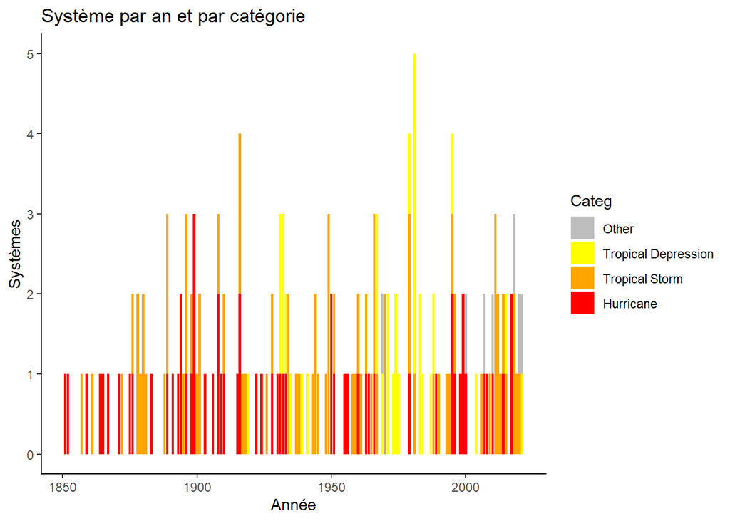

### 4.2 - Alternative “Simple”

Dans cette section nous allons établir une série temporelle contenant l’évènement annuel ayant les caractéristiques de vitesse de l’évènement le plus fort. Pour les années sans évènement nous modéliserons notre loi en partant du principe que nous observons des données tronquées (seuil 35 noeuds).

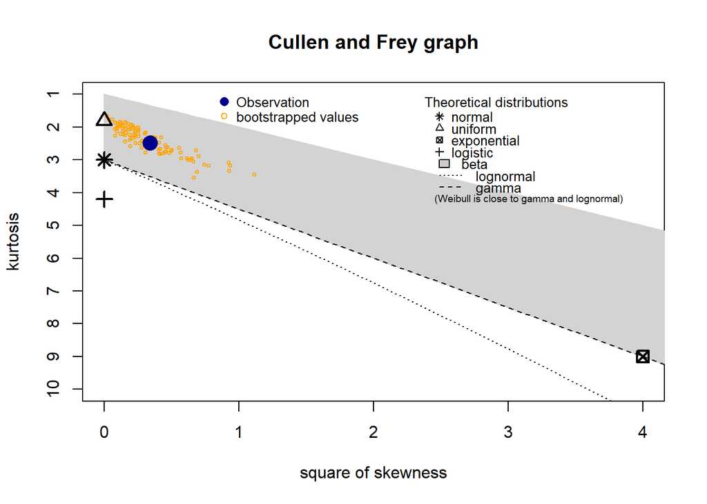

```
## summary statistics
## ------
## min:  20   max:  155
## median:  60
## mean:  66.1215
## estimated sd:  29.91583
## estimated skewness:  0.5836502
## estimated kurtosis:  2.476135
```

```r
# Base de Vent max par an depuis 1851
DT2 <- DT[,list(Wind = max(Wind)), by = Year]

# Distribution de la vitesse du vent max annuel
descdist(DT2$Wind, boot = 100)
```

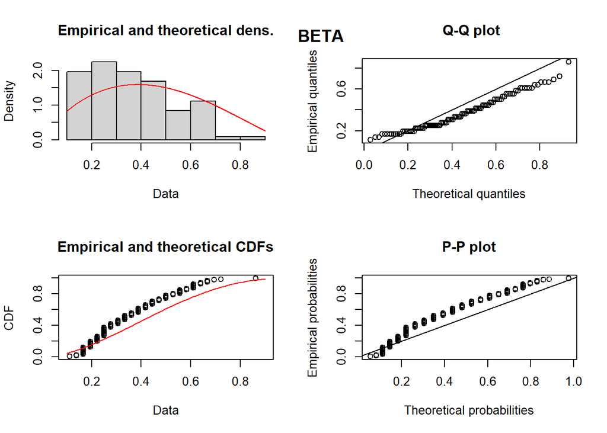

```r
maxi <- max(DT2$Wind, 180)
mini <- min(DT2$Wind, 0)
xscaled <- (DT2$Wind-mini)/maxi
fit.beta <- fitdist(xscaled, "beta",  method = "mse")
plot(fit.beta); title("BETA")
```

```r
summary(fit.beta)
```

```
## Parameters :
##        estimate
## shape1 1.882350
## shape2 2.404753
## Loglikelihood:  33.141   AIC:  -62.28201   BIC:  -56.93635
```

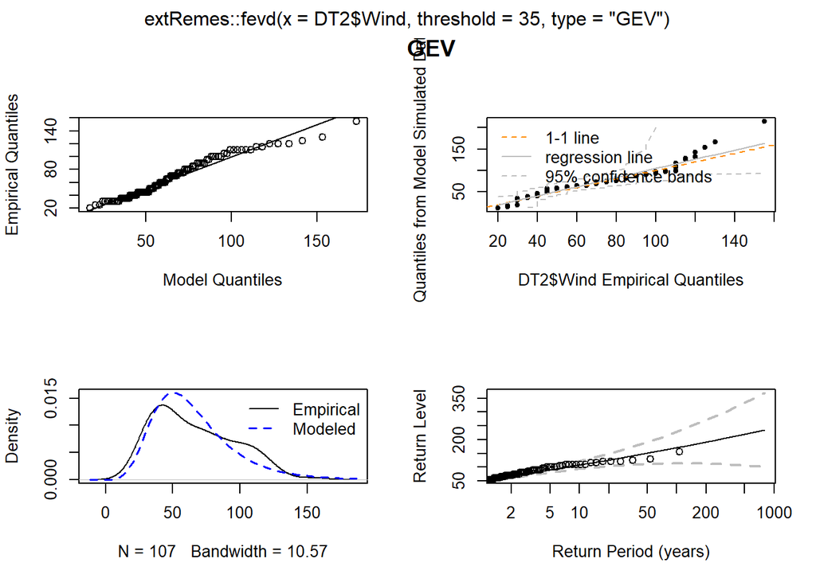

```r
fit.gev <- extRemes::fevd(DT2$Wind,type="GEV",threshold=35)
plot(fit.gev); title("GEV")
```

```r
summary(fit.gev)
```

```
##
## extRemes::fevd(x = DT2$Wind, threshold = 35, type = "GEV")
##
## [1] "Estimation Method used: MLE"
##
##
##  Negative Log-Likelihood Value:  508.4506
##
##
##  Estimated parameters:
##    location       scale       shape
## 51.52265391 23.05648622  0.05047857
##
##  Standard Error Estimates:
##  location     scale     shape
## 2.7764761 2.1856405 0.1194776
##
##  Estimated parameter covariance matrix.
##            location      scale      shape
## location  7.7088196  3.3727585 -0.1736683
## scale     3.3727585  4.7770244 -0.1350552
## shape    -0.1736683 -0.1350552  0.0142749
##
##  AIC = 1022.901
##
##  BIC = 1030.92
```

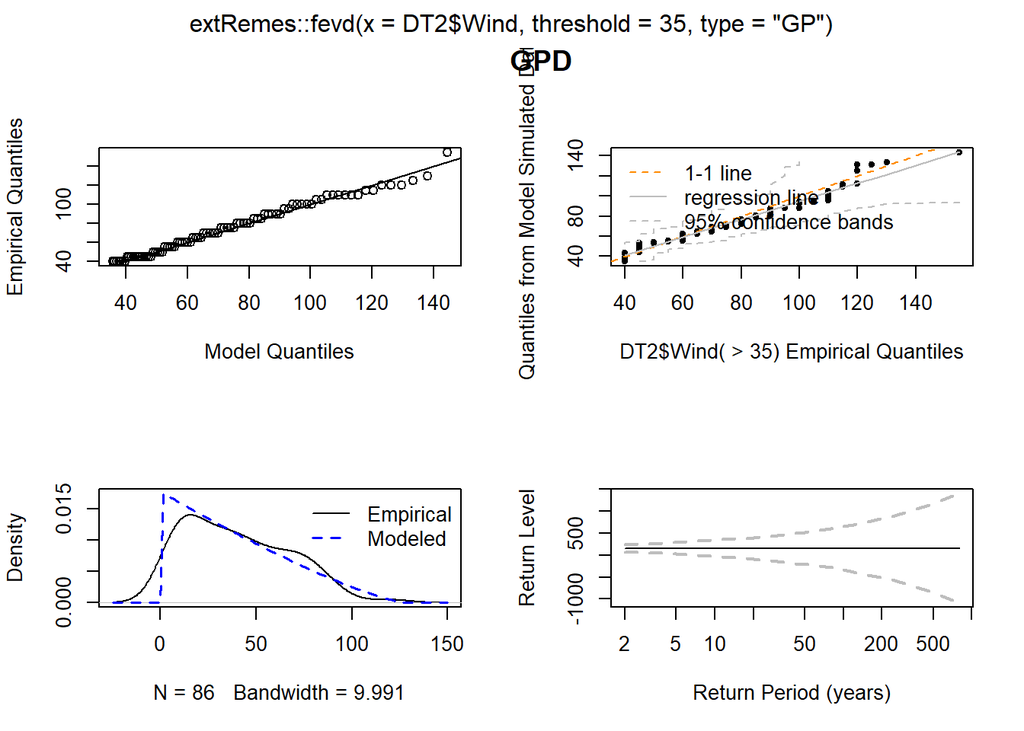

```r
fit.gpd <- extRemes::fevd(DT2$Wind,type="GP",threshold=35)
plot(fit.gpd); title("GPD")
```

```r
summary(fit.gpd)
```

```
##
## extRemes::fevd(x = DT2$Wind, threshold = 35, type = "GP")
##
## [1] "Estimation Method used: MLE"
##
##
##  Negative Log-Likelihood Value:  394.5313
##
##
##  Estimated parameters:
##      scale      shape
## 56.2299534 -0.4419421
##
##  Standard Error Estimates:
##      scale      shape
## 6.70899182 0.06990232
##
##  Estimated parameter covariance matrix.
##            scale        shape
## scale 45.0105712 -0.435730734
## shape -0.4357307  0.004886334
##
##  AIC = 793.0625
##
##  BIC = 797.9712
```

Le choix de la loi à retenir s’effectue entre la loi Beta, une GEV et la Distribution de Pareto Généralisée avec un seuil de 35 noeuds.

```r
ReturnPeriod <- data.table(rbind(
  data.frame(law = "Beta", PdR_100ans = round(maxi * qbeta(p = 0.99, fit.beta$estimate[1], fit.beta$estimate[2]) + mini, digits = 1),
             PdR_200ans = round(maxi * qbeta(p = 0.995, fit.beta$estimate[1], fit.beta$estimate[2]) + mini, digits = 1),
             PdR_max = round(1 / (1 - pbeta(q = (max(DT$Wind)-mini)/maxi, fit.beta$estimate[1], fit.beta$estimate[2])), digits = 0),
             PdR_cat4 = round(1 / (1 - pbeta(q = (113-mini)/maxi, fit.beta$estimate[1], fit.beta$estimate[2])), digits = 0),
             PdR_cat5 = round(1 / (1 - pbeta(q = (137-mini)/maxi, fit.beta$estimate[1], fit.beta$estimate[2])), digits = 0)),
  data.frame(law = "GEV", PdR_100ans = round(fExtremes::qgev(0.99, mu = fit.gev$results$par[1], beta = fit.gev$results$par[2], xi = fit.gev$results$par[3])[1], digits = 1),
             PdR_200ans = round(fExtremes::qgev(0.995, mu = fit.gev$results$par[1], beta = fit.gev$results$par[2], xi = fit.gev$results$par[3])[1], digits = 1),
             PdR_max = round(1 / (1 - fExtremes::pgev(max(DT$Wind), mu = fit.gev$results$par[1], beta = fit.gev$results$par[2], xi = fit.gev$results$par[3])),digits = 0),
             PdR_cat4 = round(1 / (1 - fExtremes::pgev(113, mu = fit.gev$results$par[1], beta = fit.gev$results$par[2], xi = fit.gev$results$par[3])),digits = 0),
             PdR_cat5 = round(1 / (1 - fExtremes::pgev(137, mu = fit.gev$results$par[1], beta = fit.gev$results$par[2], xi = fit.gev$results$par[3])),digits = 0)),
  data.frame(law = "GPD", PdR_100ans = round(evd::qgpd(0.99, loc = 35, scale = fit.gpd$results$par[1], shape = fit.gpd$results$par[2]), digits = 1),
             PdR_200ans = round(evd::qgpd(0.995, loc = 35, scale = fit.gpd$results$par[1], shape = fit.gpd$results$par[2]), digits = 1),
             PdR_max = round(1 / (1 - evd::pgpd(max(DT$Wind), loc = 35, scale = fit.gpd$results$par[1], shape = fit.gpd$results$par[2])),digits = 0),
             PdR_cat4 = round(1 / (1 - evd::pgpd(113, loc = 35, scale = fit.gpd$results$par[1], shape = fit.gpd$results$par[2])),digits = 0),
             PdR_cat5 = round(1 / (1 - evd::pgpd(137, loc = 35, scale = fit.gpd$results$par[1], shape = fit.gpd$results$par[2])),digits = 0))))

kable(ReturnPeriod)
```

| law | PdR_100ans | PdR_200ans | PdR_max | PdR_cat4 | PdR_cat5 |
| --- | --- | --- | --- | --- | --- |
| Beta | 162.9 | 167.2 | 42 | 5 | 12 |
| GEV | 170.9 | 191.5 | 58 | 13 | 30 |
| GPD | 145.6 | 150.0 | 657 | 9 | 39 |

A l’étude des courbes, la GPD a un inconvénient majeur, elle a du mal à excéder la vitesse maximale observée… Les autres méthodes permettent de calculer des périodes de retour pour des évènements de catégorie 4 et 5, tout comment les vents observables tous les 100 ou 200 ans…

Ãtant donné que l’on a parfois observé plusieurs évènements d’une intensité forte la même année, évènement n’étant pas le plus fort de l’année mais largement plus fort que les évènements d’autres années, il convient de rester prudent sur cette première approche. Elle permet toutefois de proposer une première réponse à la question du TP.

Si l’on croise ces résultats avec d’autres études, notamment celle réalisée en 2020 par la CCR, on aurait tendance à retenir la GEV, même si cette dernière semble avoir des périodes de retour plus faibles que celle de l’étude de référence. De plus, les vents annoncés pour des périodes de retour de 100 ans ou 200 ans sont supérieurs à toutes les vitesses enregistrée dans la base complète (Atlantic : Vmax = 165 kn = 305 km/h).

### 4.3 - Approche plus complète

Prenons le temps d’étudier l’intégralité des données et non plus le maximum annuel.

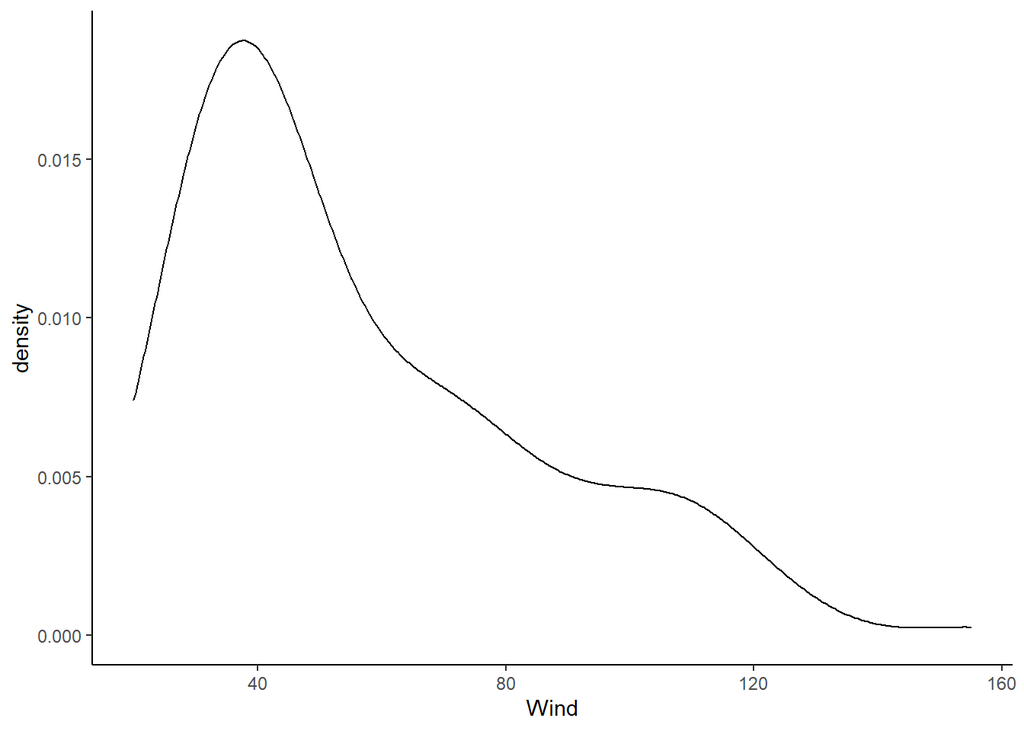

```r
# Densité de tout le set
ggplot(DT, aes(x = Wind)) + geom_density() + theme_classic()
```

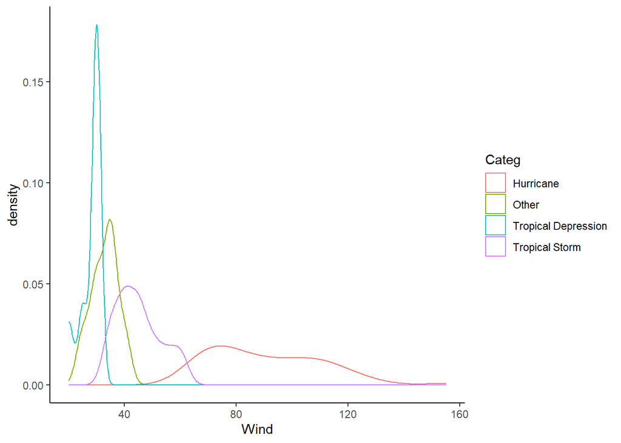

```r
# Densité de tout le set en fonction de l'intensité (non exploitable)
ggplot(DT, aes(x = Wind)) +
  geom_density(aes(color = Categ) ) + theme_classic()
```

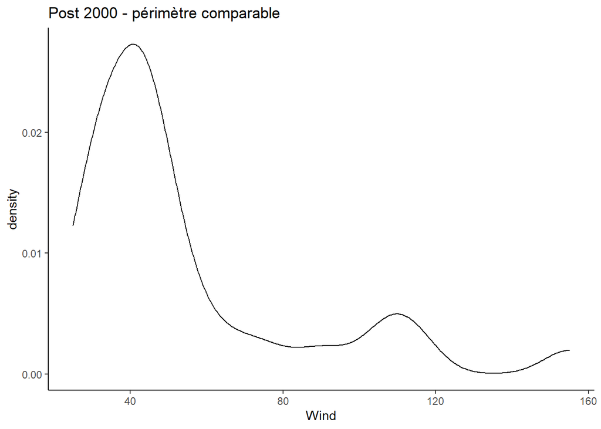

```r
# Sélection des évènements à partir de l'année 2000 (set comparable)
ggplot(DT[Year >= 2000], aes(x = Wind)) + geom_density() + theme_classic() +
  labs(title='Post 2000 - périmètre comparable')
```

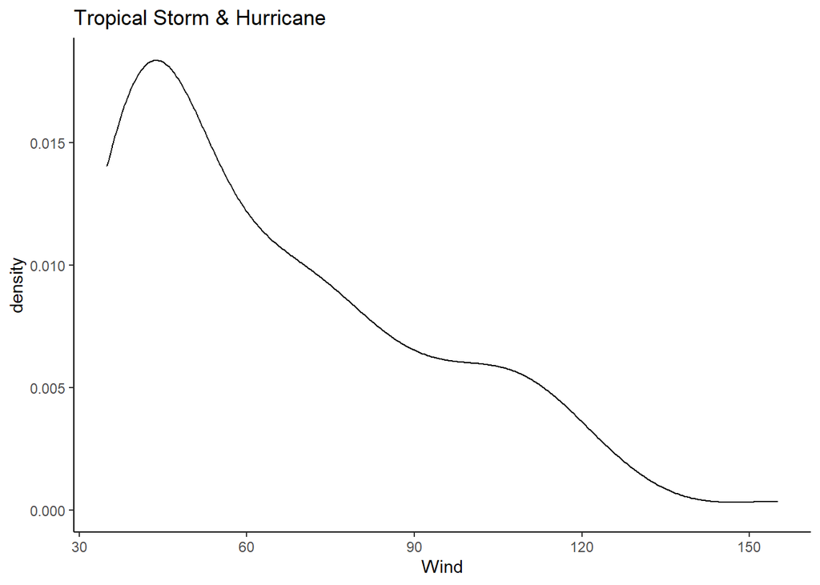

```r
# Sélection des évènements de type Tropical Storm ou Hurricane (set comparable)
ggplot(DT[Categ %in% c("Tropical Storm","Hurricane")], aes(x = Wind)) + geom_density() + theme_classic() +
  labs(title='Tropical Storm & Hurricane')
```

Nous rappellerons qu’en 4.1 nous avons identifié que l’historique ancien n’était pas à périmètre identique de l’historique récent. Ces graphiques montrent le lien immédiat entre la catégorie (fonction du vent) et la vitesse du vent. Concernant les données récentes, la distribution s’écarte assez fortement de la distribution complète (et tronquées), ce qui semble moins le cas de la distribution des évènements “majeurs” (type “Tropical Storm” **TS** et “Hurricane” **HU**).

**L’idée ici serait de construire une approche Bayésienne du système.**

La difficulté de l’exercice est de mettre sous forme d’équation notre problématique.  
Posons X la vitesse de vent maximale au passage dans la zone de danger et Y la catégorie de l’évènement.

$P(X|Y)=\frac{P(Y|X).P(X)}{P(Y)}$

Nous pouvons donc à ajuster $P(X \ge x|Y=y)$ la probabilité que X dépasse x noeuds, sachant que les évènements sont de type Tempête Tropicale ou Ouragan.  
Nous cherchons cependant à ajuster $P(X\ge x)$ quelle que soit la catégorie y de Y…  
La probabilité $P(Y=y)$ peut s’ajuster sur un set plus récent et complet et se traduire comme la probabilité qu’un évènement depuis 2000 soit de type Tempête Tropicale ou Ouragan.

La dernière partie de l’équation, soit $P(Y=y|X>x)$ est elle instantanée puisque par construction, la catégorie est définie par la vitesse du vent. Ainsi, dès que la vitesse atteint 34 noeuds le système peut être considéré comme Tempête Tropicale ou Ouragan.

On pourra alors définir $P(X\ge x) = P(Y=y) * \frac{P(X\ge x|Y=y)}{P(Y=y|X\ge x)}$ avec pour x > 34 $P(Y=y|X\ge x) = 1$.

**A ce stade nous avons 2 options**, la première consiste à estimer empiriquement $P(Y=y)$ de sorte que sur l’ensemble des évènements observés depuis l’an 2000, la probabilité d’observer un évènement de type **TS** ou **HU** soit le nombre de ces évènements rapporté au nombre total d’évènements observé sur la période.

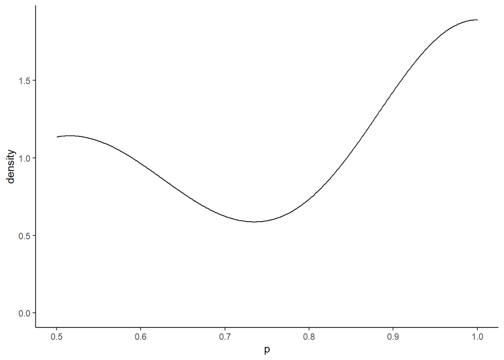

```r
# P(Y) : période d'analyse 2000 - 2021
Y_est <- DT[Year >= 2000 & Categ %in% c("Tropical Storm","Hurricane"), list(N = length(Key))] / DT[Year >= 2000, list(N = length(Key))]

Y <- merge(DT[Year >= 2000 & Categ %in% c("Tropical Storm","Hurricane"), list(N_y = length(Key)),by = list(Year)], DT[Year >= 2000, list(N = length(Key)),by = list(Year)], by = "Year")
Y$p <- Y$N_y/Y$N

ggplot(Y, aes(x = p)) +
  geom_density() + theme_classic()
```

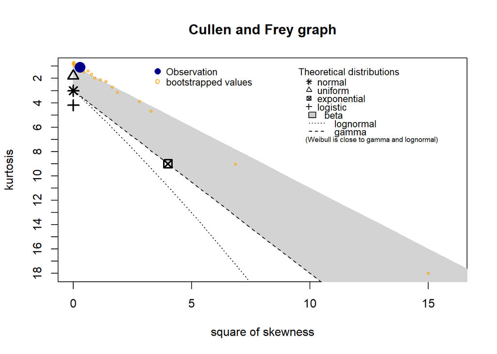

```
## summary statistics
## ------
## min:  0.5   max:  1
## median:  1
## mean:  0.8111111
## estimated sd:  0.2428883
## estimated skewness:  -0.5344634
## estimated kurtosis:  1.085245
```

```r
descdist(Y$p, boot = 100)
```

```
## Fitting of the distribution ' beta ' by matching moments
## Parameters :
##         estimate
## shape1 1.4458146
## shape2 0.3366966
## Loglikelihood:  Inf   AIC:  -Inf   BIC:  -Inf
```

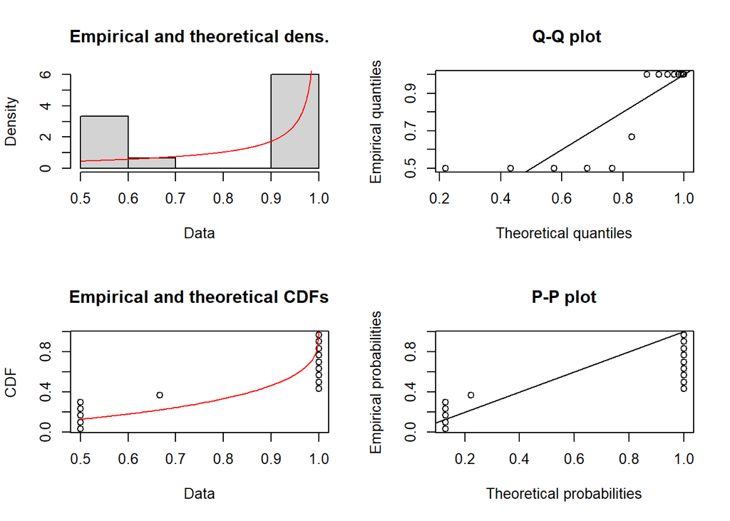

```r
fit.beta <- fitdist(Y$p, "beta", method = "mme");summary(fit.beta);plot(fit.beta)
```

En posant, comme dans le support de cours, **Y~B(n,p)** avec n le nombre d’évènement par an (que l’on notera Z) et p la probabilité qu’un évènement n dépasse le seuil d’une Tempête Tropicale (**TS**), nous obtenons **p = 70%**

Si l’on s’attarde sur les chiffres, on notera que si 1 seul système traverse la zone il a historiquement 100% de probabilité d’être de type **TS** ou **HU**, cette probabilité est presque la même pour les années avec 3 évènements… Il reste les années à 2 exercices oÃ¹ 3 fois sur 8 la proba est de 100% et 5 fois sur 8 elle est de 50%…

Toutefois, on note dans ce calcul que selon les années cette valeur oscille entre 50% et 100%, ce qui laisse penser que la probabilité d’observer un évènement de type **TS** ou **HU** est dépendant du nombre total de système dans l’année. Ce qui nous amène à la seconde option.

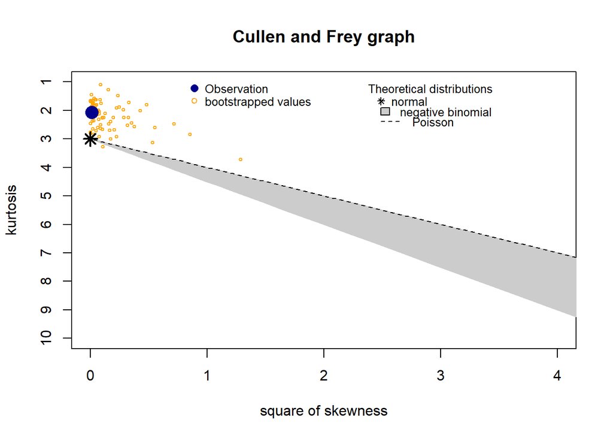

```
## summary statistics
## ------
## min:  0   max:  3
## median:  1.5
## mean:  1.363636
## estimated sd:  0.9534626
## estimated skewness:  -0.1138707
## estimated kurtosis:  2.066406
```

```r
# P(Z) : période d'analyse 2000 - 2021
Z <- DT[Year >= 2000, list(N = length(Key)), by = list(Year)]
# La série est incomplète : on ajoute les années sans système
Z <- setorderv(rbind(data.table(Year=2000:2021,N=0)[!Year%in%(Z$Year)], Z),"Year")
# mean(Z$N)
# sd(Z$N)
# A priori mu est différent de sigma donc on privilégirait une loi Binomiale Négative
descdist(Z$N, discrete=T, boot = 100)
```

```r
fit.poisson <- fitdist(Z$N, "pois");summary(fit.poisson)
```

```
## Fitting of the distribution ' pois ' by maximum likelihood
## Parameters :
##        estimate Std. Error
## lambda 1.363636  0.2489647
## Loglikelihood:  -30.5172   AIC:  63.03439   BIC:  64.12543
```

```r
fit.negbin <- fitdist(Z$N, "nbinom");summary(fit.negbin)
```

```
## Fitting of the distribution ' nbinom ' by maximum likelihood
## Parameters :
##          estimate Std. Error
## size 2.222582e+06        NaN
## mu   1.363627e+00   0.248963
## Loglikelihood:  -30.5172   AIC:  65.0344   BIC:  67.21648
## Correlation matrix:
##      size  mu
## size    1 NaN
## mu    NaN   1
```

```r
fit.norm <- fitdist(Z$N, "norm", discrete = T);summary(fit.norm)
```

```
## Fitting of the distribution ' norm ' by maximum likelihood
## Parameters :
##      estimate Std. Error
## mean 1.363636  0.1986052
## sd   0.931541  0.1404344
## Loglikelihood:  -29.65652   AIC:  63.31303   BIC:  65.49512
## Correlation matrix:
##      mean sd
## mean    1  0
## sd      0  1
```

```r
# Après execution : l'AIC le plus faible est celui de la loi de Poisson que l'on retiendra donc

fit.Z <- fit.poisson
fit.Z$estimate
```

```
##   lambda
## 1.363636
```

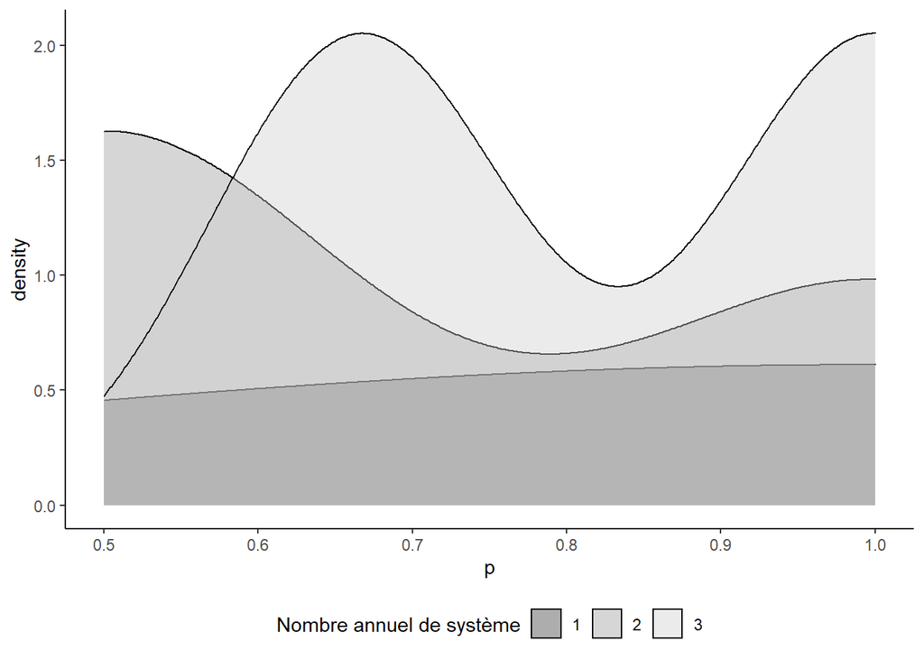

```r
# Le nombre d'évènement (tous types confondus) par an pourrait suivre une loi de Poisson.

ggplot(Y, aes(x = p, fill = as.factor(N))) +
  geom_density(alpha=0.4) + scale_fill_grey() + theme_classic() +
  labs(fill="Nombre annuel de système") +
  theme(legend.position="bottom")
```

```r
# Il semble compliqué d'établir une loi par nombre annuel d'évènement sur aussi peu d'historique...
Y_est_N <- Y[,list(Y_est = sum(N_y)/sum(N), Y_sd = sd(p)),by = list(n=N)]
# Avec ces paramètres il reste possible d'effectuer des tirages aléatoires selon des lois uniformes, normales, binomiales négatives ou de Poisson.

# NB : que faire si Z > 3 ?
dpois(4:10,fit.Z$estimate)
```

```
## [1] 3.684371e-02 1.004828e-02 2.283701e-03 4.448768e-04 7.583127e-05
## [6] 1.148959e-05 1.566762e-06
```

```r
# environ 5% des tirages poserons question
```

A ce stade, nous pouvons définir une probabilité conditionnelle mais uniquement pour les années ayant 1 à 3 systèmes. Si Z >= 4 alors nous sommes coincés. Une approche par la théorie de la crédibilité pourrait être testée, cela semble complexe à développer en cours. Nous avons toutefois une distribution classique de Z telle que $Z ~~suit~ Poisson(\lambda)$.

A partir de lÃ , nous disposons donc d’un loi de distribution de Z et de Y et de Y sachant Z, les lois de Z sachant Y et de Y sachant X sont équivalentes à des indicatrices. Par conséquent, si nous ajustons la loi de X sachant Y, nous pourrons alors remonter à la loi de X, le plus simple étant d’opter pour une approche par simulation.

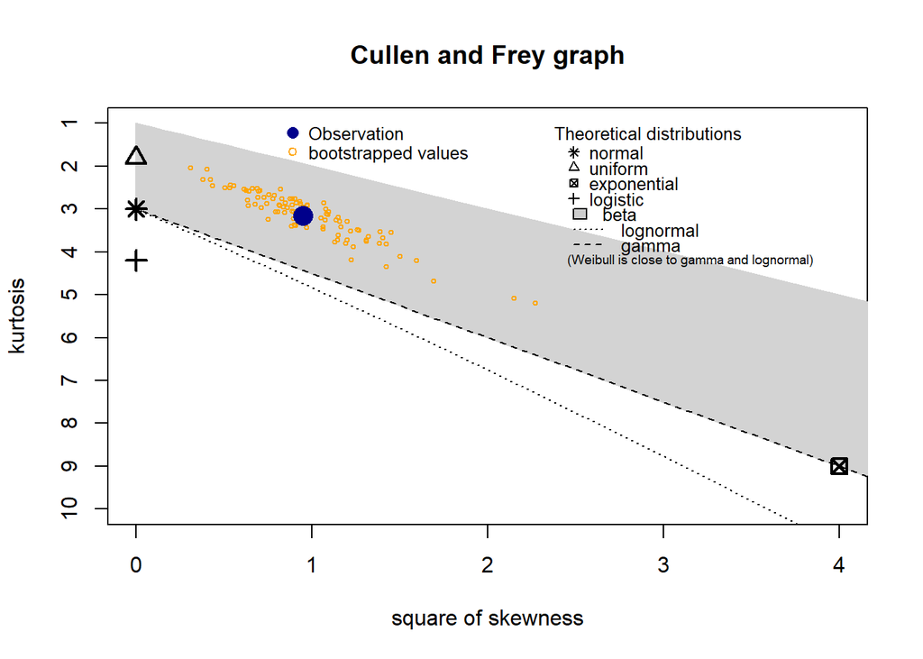

```
## summary statistics
## ------
## min:  20   max:  155
## median:  45
## mean:  57.0977
## estimated sd:  28.31076
## estimated skewness:  0.9740342
## estimated kurtosis:  3.15979
```

```r
# Cette étape est la même que la 4.2 toutefois elle s'applique sur toutes les données

# Distribution de la vitesse du vent max annuel
descdist(DT$Wind, boot = 100)
```

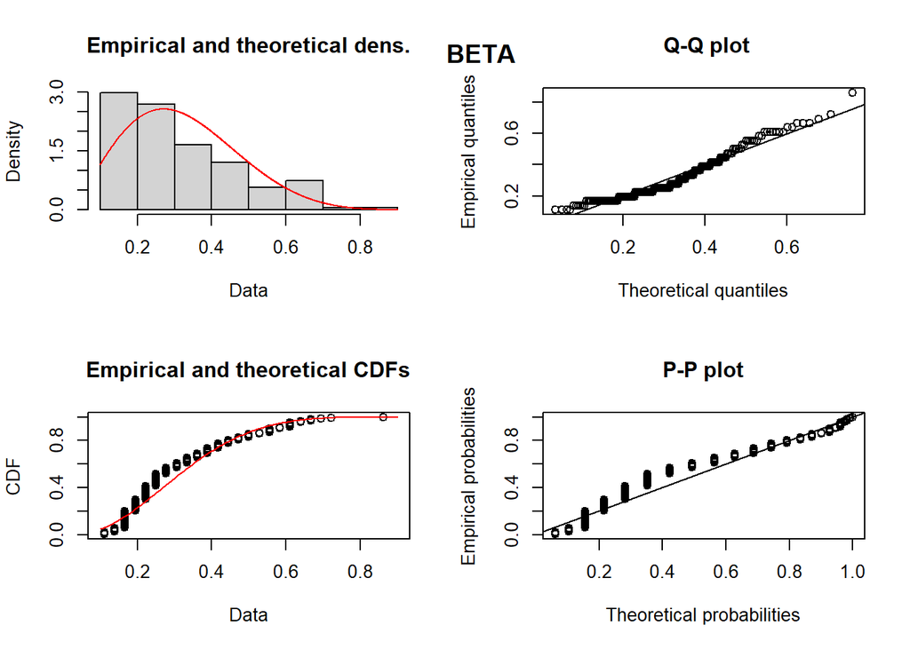

```r
maxi <- max(DT$Wind, 180)
mini <- min(DT$Wind, 0)
xscaled <- (DT$Wind-mini)/maxi
fit.beta <- fitdist(xscaled, "beta",  method = "mle")
plot(fit.beta); title("BETA")
```

```r
summary(fit.beta)
```

```
## Fitting of the distribution ' beta ' by maximum likelihood
## Parameters :
##        estimate Std. Error
## shape1 2.862296  0.2920949
## shape2 6.034808  0.6447685
## Loglikelihood:  91.14238   AIC:  -178.2848   BIC:  -171.9666
## Correlation matrix:
##           shape1    shape2
## shape1 1.0000000 0.8799209
## shape2 0.8799209 1.0000000
```

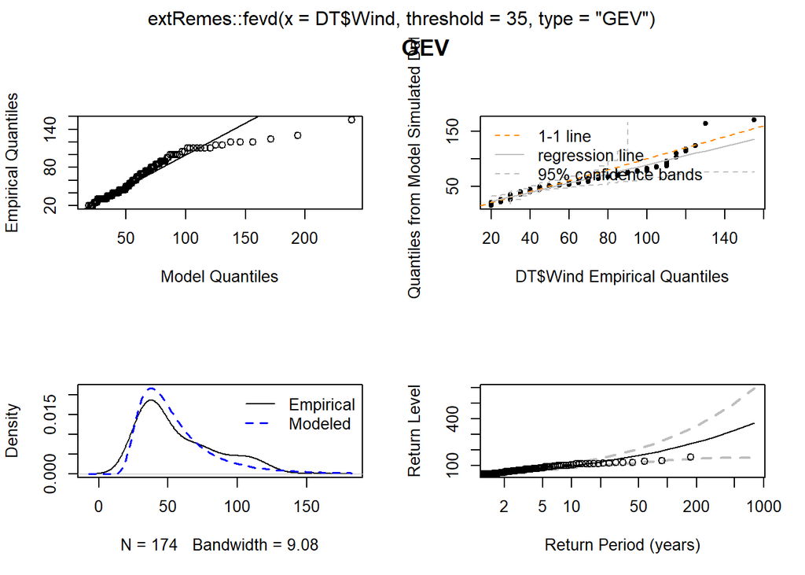

```r
fit.gev <- extRemes::fevd(DT$Wind,type="GEV",threshold=35)
plot(fit.gev); title("GEV")
```

```r
summary(fit.gev)
```

```
##
## extRemes::fevd(x = DT$Wind, threshold = 35, type = "GEV")
##
## [1] "Estimation Method used: MLE"
##
##
##  Negative Log-Likelihood Value:  799.4294
##
##
##  Estimated parameters:
##   location      scale      shape
## 41.7706287 17.4648129  0.2719066
##
##  Standard Error Estimates:
##  location     scale     shape
## 1.5725660 1.3211510 0.0815116
##
##  Estimated parameter covariance matrix.
##            location       scale       shape
## location  2.4729639  1.35554092 -0.05053210
## scale     1.3555409  1.74544002 -0.02067647
## shape    -0.0505321 -0.02067647  0.00664414
##
##  AIC = 1604.859
##
##  BIC = 1614.336
```

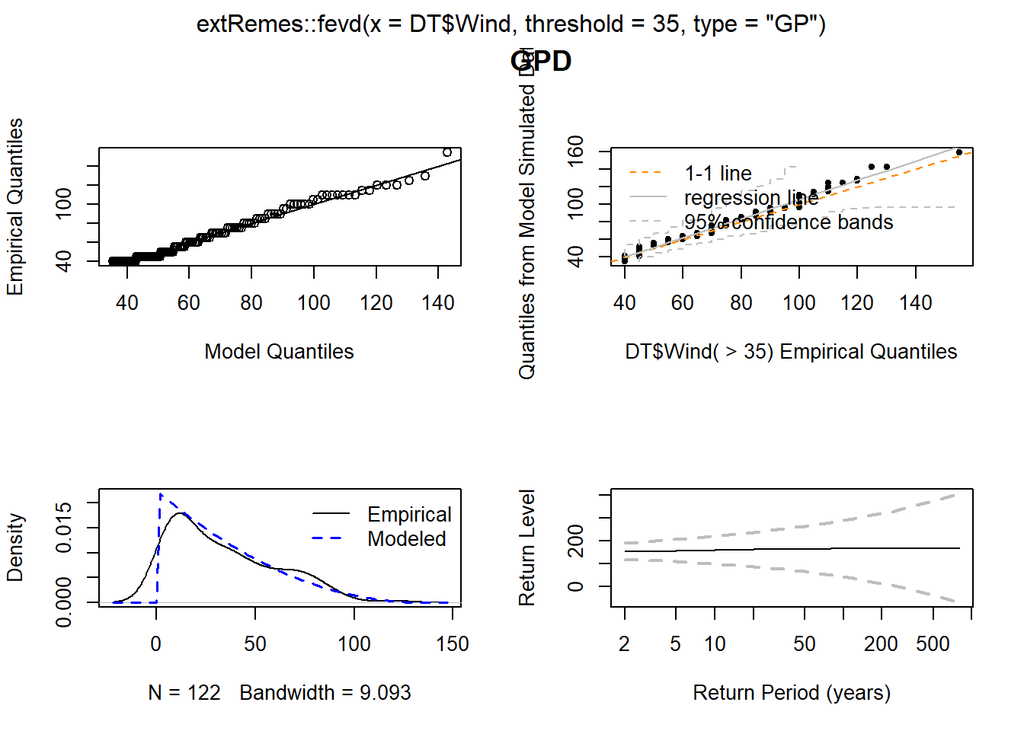

```r
fit.gpd <- extRemes::fevd(DT$Wind,type="GP",threshold=35)
plot(fit.gpd); title("GPD")
```

```r
summary(fit.gpd)
```

```
##
## extRemes::fevd(x = DT$Wind, threshold = 35, type = "GP")
##
## [1] "Estimation Method used: MLE"
##
##
##  Negative Log-Likelihood Value:  545.1395
##
##
##  Estimated parameters:
##      scale      shape
## 44.4914349 -0.3271973
##
##  Standard Error Estimates:
##      scale      shape
## 4.78770796 0.06533496
##
##  Estimated parameter covariance matrix.
##            scale        shape
## scale 22.9221475 -0.270070847
## shape -0.2700708  0.004268657
##
##  AIC = 1094.279
##
##  BIC = 1099.887
```

Il ressort que la **loi Beta semble plus adaptée** à cette modélisation, on fera cependant attention aux ordre de grandeur de l’AIC, les données étant transformée pour l’ajustement de la loi Beta. Nous noterons que la distribution de Pareto Généralisée conserve les même défauts que précédemment, notamment sur la queue de distribution. Concernant l’approche par GEV, elle démontre des difficultés à expliquer les vents extrêmes. Nous noterons que le graphe des période de retour place les points forts dans le bas de l’intervalle de confiance. En restant prudent, cela peut venir de la stationnarité des données, le changement climatique engendrant des écarts entre l’historique lointain et les données récentes.

```r
# Nous ajouterons à la probabilité P(Z>0) : 1-ppois(0, fit.Z$estimate)

Zajust <- 1-ppois(0, fit.Z$estimate)

# Etant donné que nous travaillons sur une loi en combinant 2, il ne sera pas possible de passer par le quantile, on va donc écrire des équations à résoudre

f.beta <- function(x) {
  y <- 1 / (Zajust*(1 - pbeta(q = x, fit.beta$estimate[1], fit.beta$estimate[2])))
  return(y)
}

f.gev <- function(x) {
  y <- 1 / (Zajust*(1 - extRemes::pevd(x, threshold = 35, loc = fit.gev$results$par[1], scale = fit.gev$results$par[2], shape = fit.gev$results$par[3], type = "GEV")))
  return(y)
}

f.gpd <- function(x) {
  y <- 1 / (Zajust*(1 - extRemes::pevd(x, threshold = 35, scale = fit.gpd$results$par[1], shape = fit.gpd$results$par[2], type = "GP")))
  return(y)
}

inverse = function(fn, interval = NULL, lower = min(interval), upper = max(interval), ...){
    Vectorize(function(y){
        uniroot(f=function(x){fn(x)-y}, lower=lower, upper=upper, ...)$root
    })
}

f.betainv = inverse(f.beta, lower = 0, upper =250)
f.gevinv = inverse(f.gev, lower = 0, upper =250)
f.gpdinv = inverse(f.gpd, lower = 0, upper =250)

ReturnPeriod2 <- data.table(rbind(
  data.frame(law = "Beta", PdR_100ans = round(maxi*f.betainv(100)+mini,digits = 1),
             PdR_200ans = round(maxi*f.betainv(200)+mini,digits = 1),
             PdR_max = round(f.beta((max(DT$Wind)-mini)/maxi),digits = 0),
             PdR_cat4 = round(f.beta((113-mini)/maxi),digits = 0),
             PdR_cat5 = round(f.beta((137-mini)/maxi),digits = 0)),
  data.frame(law = "GEV", PdR_100ans = round(f.gevinv(100),digits = 1),
             PdR_200ans = round(f.gevinv(200),digits = 1),
             PdR_max = round(f.gev(max(DT$Wind)),digits = 0),
             PdR_cat4 = round(f.gev(113),digits = 0),
             PdR_cat5 = round(f.gev(137),digits = 0)),
  data.frame(law = "GPD", PdR_100ans = round(f.gpdinv(100),digits = 1),
             PdR_200ans = round(f.gpdinv(200),digits = 1),
             PdR_max = round(f.gpd(max(DT$Wind)),digits = 0),
             PdR_cat4 = round(f.gpd(113),digits = 0),
             PdR_cat5 = round(f.gpd(137),digits = 0))))


kable(ReturnPeriod2)
```

| law | PdR_100ans | PdR_200ans | PdR_max | PdR_cat4 | PdR_cat5 |
| --- | --- | --- | --- | --- | --- |
| Beta | 122.5 | 129.4 | 10657 | 45 | 488 |
| GEV | 184.5 | 227.7 | 57 | 22 | 39 |
| GPD | 137.8 | 144.5 | 934 | 18 | 93 |

## Conclusion

La prochaine étape, maintenant que nous avons une estimation sur l’aléa (le risque Ouragan) consiste à estimer les pertes associées à ces évènements.